# Assignment4

Jordi Florit Ensenyat, Josep Gabriel Fornes Reynes and Pau Girón Rodríguez

2024-12-02

## **1. Introduction**

This assignment explores the penguindata dataset, which contains measurements of penguins in the Palmer Archipelago. These data provide valuable insights into various physical attributes of penguins, as well as contextual information such as their sex and the year of study.

### **1.1. Variable information**

**1. bill length mm**: a number denoting bill length (millimeters)

**2. bill depth mm**: a number denoting bill depth (millimeters)

**3. ipper length mm**: an integer denoting ipper length (millimeters)

**4. body mass g**: an integer denoting body mass (grams)

**5. sex**: a factor denoting penguin sex (female, male)

**6. year**: an integer denoting the study year (2007, 2008, or 2009)

### **1.2. Research Question**

**How can the penguins be grouped?**

To address this question, this analysis will apply various clustering techniques, including both partitional and hierarchical methods. Each approach will be tested with different parameters to assess its effectiveness and to identify meaningful groupings within the dataset.

Key points to be addressed include:

- **Preprocessing the data**: Ensuring the dataset is ready for analysis by handling missing values, scaling variables, and addressing categorical data.
- **Exploration of clustering models**: Applying and comparing different clustering methods to identify the most meaningful groupings.
- **Parameter optimization**: Testing multiple configurations for each clustering method to determine the best-performing models.
- **Comparison of results**: Analyzing the similarities and differences in the clusters produced by different methods.
- **Number of clusters**: Evaluating how the choice of the number of clusters affects the results and their interpretability.

## **2. Data Analisis**

### **2.1. Importing Data**

```r
# Load the necessary libraries and read the CSV file containing the loan data
library(patchwork)
library(tidyr)
library(GGally)
```

```r
library(ggplot2)
library(dplyr)
library(gridExtra)
library(dendextend)
library(dbscan)
library(factoextra)
library(mclust)
library(cluster)
library(igraph)
library(ggcorrplot)
library(viridis)
data <- read.csv("penguindata.csv")
```

This is one simple example of the dataset:

```r
# Display the structure of the dataset
head(data)
```

```
##   X bill_length_mm bill_depth_mm flipper_length_mm body_mass_g    sex year
## 1 1           39.1          18.7               181        3750   male 2007
## 2 2           39.5          17.4               186        3800 female 2007
## 3 3           40.3          18.0               195        3250 female 2007
## 4 4             NA            NA                NA          NA   <NA> 2007
## 5 5           36.7          19.3               193        3450 female 2007
## 6 6           39.3          20.6               190        3650   male 2007
```

This is the format of the data:

```r
# Display the structure of the dataset
str(data)
```

```
## 'data.frame':    344 obs. of  7 variables:
##  $ X                : int  1 2 3 4 5 6 7 8 9 10 ...
##  $ bill_length_mm   : num  39.1 39.5 40.3 NA 36.7 39.3 38.9 39.2 34.1 42 ...
##  $ bill_depth_mm    : num  18.7 17.4 18 NA 19.3 20.6 17.8 19.6 18.1 20.2 ...
##  $ flipper_length_mm: int  181 186 195 NA 193 190 181 195 193 190 ...
##  $ body_mass_g      : int  3750 3800 3250 NA 3450 3650 3625 4675 3475 4250 ...
##  $ sex              : chr  "male" "female" "female" NA ...
##  $ year             : int  2007 2007 2007 2007 2007 2007 2007 2007 2007 2007 ...
```

The summary data. The summary() function gives a statistical summary of each column, including minimum, maximum, mean, and quartiles.

```r
# Display a statistical summary of each column, including minimum, maximum, mean, and quartiles
summary(data)
```

```
##        X          bill_length_mm  bill_depth_mm   flipper_length_mm
##  Min.   :  1.00   Min.   :32.10   Min.   :13.10   Min.   :172.0
##  1st Qu.: 86.75   1st Qu.:39.23   1st Qu.:15.60   1st Qu.:190.0
##  Median :172.50   Median :44.45   Median :17.30   Median :197.0
##  Mean   :172.50   Mean   :43.92   Mean   :17.15   Mean   :200.9
##  3rd Qu.:258.25   3rd Qu.:48.50   3rd Qu.:18.70   3rd Qu.:213.0
##  Max.   :344.00   Max.   :59.60   Max.   :21.50   Max.   :231.0
##                   NA's   :2       NA's   :2       NA's   :2
##   body_mass_g       sex                 year
##  Min.   :2700   Length:344         Min.   :2007
##  1st Qu.:3550   Class :character   1st Qu.:2007
##  Median :4050   Mode  :character   Median :2008
##  Mean   :4202                      Mean   :2008
##  3rd Qu.:4750                      3rd Qu.:2009
##  Max.   :6300                      Max.   :2009
##  NA's   :2
```

Some charts to visualize the numeric variables.

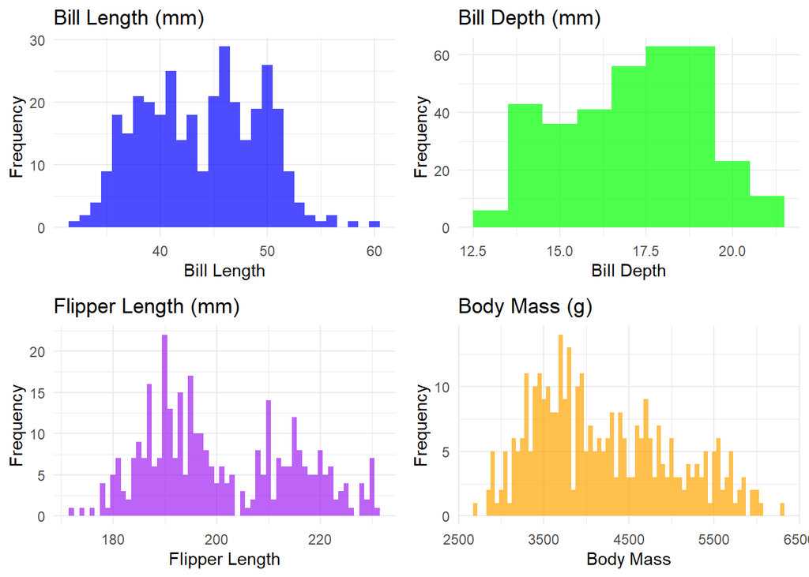

```r
# Create histograms for each variable
plot_bill_length <- ggplot(data, aes(x = bill_length_mm)) +
  geom_histogram(binwidth = 1, fill = "blue", alpha = 0.7) +
  labs(title = "Bill Length (mm)", x = "Bill Length", y = "Frequency") +
  theme_minimal()

plot_bill_depth <- ggplot(data, aes(x = bill_depth_mm)) +
  geom_histogram(binwidth = 1, fill = "green", alpha = 0.7) +
  labs(title = "Bill Depth (mm)", x = "Bill Depth", y = "Frequency") +
  theme_minimal()

plot_flipper_length <- ggplot(data, aes(x = flipper_length_mm)) +
  geom_histogram(binwidth = 1, fill = "purple", alpha = 0.7) +
  labs(title = "Flipper Length (mm)", x = "Flipper Length", y = "Frequency") +
  theme_minimal()

plot_body_mass <- ggplot(data, aes(x = body_mass_g)) +
  geom_histogram(binwidth = 50, fill = "orange", alpha = 0.7) +
  labs(title = "Body Mass (g)", x = "Body Mass", y = "Frequency") +
  theme_minimal()

# Arrange the plots in a grid
# Combine all the plots in a grid
grid.arrange(
  plot_bill_length, plot_bill_depth, plot_flipper_length,
  plot_body_mass,
  ncol = 2
)
```

This data-set contains some missing values and some categories. So now, let’s clean up that data.

### **2.2. Outliers**

As we can see in the summary, there are no columns with values outside the normal. Let’s visualize the box plot charts.

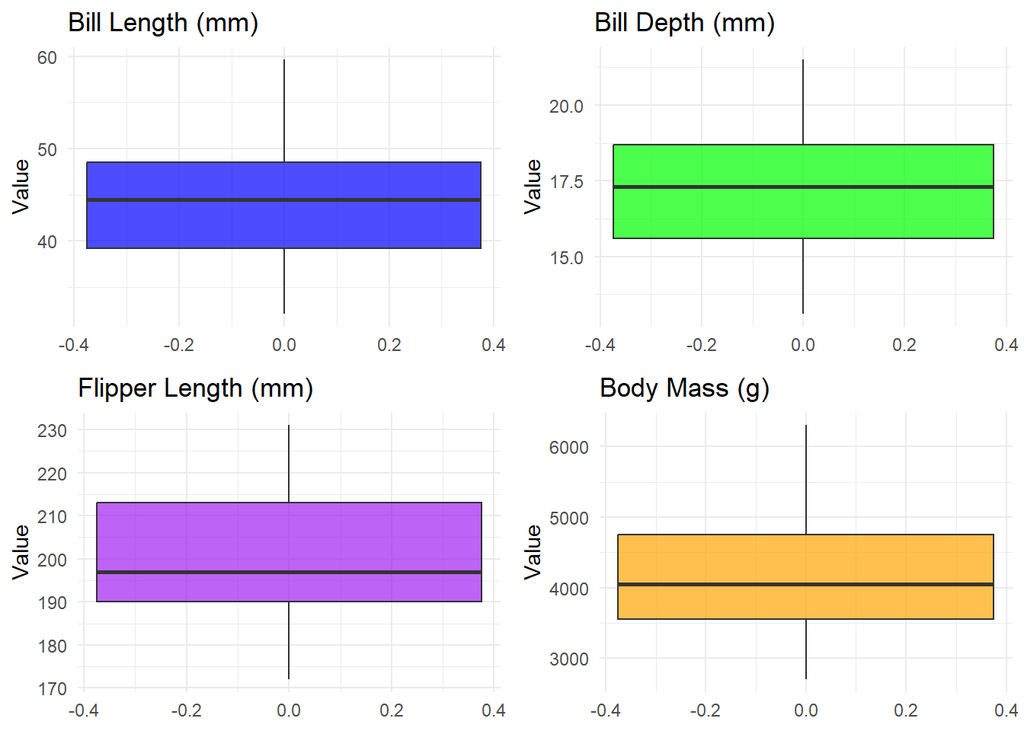

```r
# Create boxplots for each variable
plot_bill_length <- ggplot(data, aes(y = bill_length_mm)) +
  geom_boxplot(fill = "blue", alpha = 0.7, outlier.color = "red", outlier.shape = 19) +
  labs(title = "Bill Length (mm)", y = "Value") +
  theme_minimal()

plot_bill_depth <- ggplot(data, aes(y = bill_depth_mm)) +
  geom_boxplot(fill = "green", alpha = 0.7, outlier.color = "red", outlier.shape = 19) +
  labs(title = "Bill Depth (mm)", y = "Value") +
  theme_minimal()

plot_flipper_length <- ggplot(data, aes(y = flipper_length_mm)) +
  geom_boxplot(fill = "purple", alpha = 0.7, outlier.color = "red", outlier.shape = 19) +
  labs(title = "Flipper Length (mm)", y = "Value") +
  theme_minimal()

plot_body_mass <- ggplot(data, aes(y = body_mass_g)) +
  geom_boxplot(fill = "orange", alpha = 0.7, outlier.color = "red", outlier.shape = 19) +
  labs(title = "Body Mass (g)", y = "Value") +
  theme_minimal()

# Arrange the plots in a grid
grid.arrange(
  plot_bill_length, plot_bill_depth,
  plot_flipper_length, plot_body_mass,
  ncol = 2
)
```

### **2.3. Missing Values**

Let’s process the missing values. These are the missing values

```r
# Identify missing values
colSums(is.na(data))
```

```
##                 X    bill_length_mm     bill_depth_mm flipper_length_mm
##                 0                 2                 2                 2
##       body_mass_g               sex              year
##                 2                11                 0
```

After some investigation of the data, we have detected that the missing values of the numerical columns match in the same row. So we’ve considered deleting those two rows and then treating the gender column.

So let’s modify them.

```r
# Remove rows with missing values in numeric columns
data <- data %>% filter(!is.na(bill_length_mm) &
                        !is.na(bill_depth_mm) &
                        !is.na(flipper_length_mm) &
                        !is.na(body_mass_g))

colSums(is.na(data))
```

```
##                 X    bill_length_mm     bill_depth_mm flipper_length_mm
##                 0                 0                 0                 0
##       body_mass_g               sex              year
##                 0                 9                 0
```

In index 4 we could see that the row had missing values, but now we can verify that that row has been deleted.

```r
head(data)
```

```
##   X bill_length_mm bill_depth_mm flipper_length_mm body_mass_g    sex year
## 1 1           39.1          18.7               181        3750   male 2007
## 2 2           39.5          17.4               186        3800 female 2007
## 3 3           40.3          18.0               195        3250 female 2007
## 4 5           36.7          19.3               193        3450 female 2007
## 5 6           39.3          20.6               190        3650   male 2007
## 6 7           38.9          17.8               181        3625 female 2007
```

As we can see, we have removed the two rows with null values. Now let’s deal with the remaining 9 values of the variable `sex`.

```r
data <- data %>% mutate(sex = ifelse(is.na(sex),
                                     as.character(names(which.max(table(sex)))),
                                     as.character(sex)))

summary(data)
```

```
##        X          bill_length_mm  bill_depth_mm   flipper_length_mm
##  Min.   :  1.00   Min.   :32.10   Min.   :13.10   Min.   :172.0
##  1st Qu.: 87.25   1st Qu.:39.23   1st Qu.:15.60   1st Qu.:190.0
##  Median :172.50   Median :44.45   Median :17.30   Median :197.0
##  Mean   :172.70   Mean   :43.92   Mean   :17.15   Mean   :200.9
##  3rd Qu.:257.75   3rd Qu.:48.50   3rd Qu.:18.70   3rd Qu.:213.0
##  Max.   :344.00   Max.   :59.60   Max.   :21.50   Max.   :231.0
##   body_mass_g       sex                 year
##  Min.   :2700   Length:342         Min.   :2007
##  1st Qu.:3550   Class :character   1st Qu.:2007
##  Median :4050   Mode  :character   Median :2008
##  Mean   :4202                      Mean   :2008
##  3rd Qu.:4750                      3rd Qu.:2009
##  Max.   :6300                      Max.   :2009
```

The column does contain categorical data (“male”, “female”), so we replace it with the mode (the most frequent value in the column).

We can verify that they have been modified correctly

```r
# Identify missing values
colSums(is.na(data))
```

```
##                 X    bill_length_mm     bill_depth_mm flipper_length_mm
##                 0                 0                 0                 0
##       body_mass_g               sex              year
##                 0                 0                 0
```

### **2.4. Categorical Variables**

Finally, we are going to convert the categorical variables to numerical ones. Firstly, we only see one categorical variable (`sex`), but since the `year` variable only has three years (2007, 2008 and 2009) we are going to treat it as a categorical variable.

First, we convert the sex and year to factor and then we convert it to numeric.

```r
data$sex <- as.numeric(as.factor(data$sex))
data$year <- as.numeric(as.factor(data$year))

summary(data)
```

```
##        X          bill_length_mm  bill_depth_mm   flipper_length_mm
##  Min.   :  1.00   Min.   :32.10   Min.   :13.10   Min.   :172.0
##  1st Qu.: 87.25   1st Qu.:39.23   1st Qu.:15.60   1st Qu.:190.0
##  Median :172.50   Median :44.45   Median :17.30   Median :197.0
##  Mean   :172.70   Mean   :43.92   Mean   :17.15   Mean   :200.9
##  3rd Qu.:257.75   3rd Qu.:48.50   3rd Qu.:18.70   3rd Qu.:213.0
##  Max.   :344.00   Max.   :59.60   Max.   :21.50   Max.   :231.0
##   body_mass_g        sex             year
##  Min.   :2700   Min.   :1.000   Min.   :1.000
##  1st Qu.:3550   1st Qu.:1.000   1st Qu.:1.000
##  Median :4050   Median :2.000   Median :2.000
##  Mean   :4202   Mean   :1.518   Mean   :2.029
##  3rd Qu.:4750   3rd Qu.:2.000   3rd Qu.:3.000
##  Max.   :6300   Max.   :2.000   Max.   :3.000
```

```r
str(data)
```

```
## 'data.frame':    342 obs. of  7 variables:
##  $ X                : int  1 2 3 5 6 7 8 9 10 11 ...
##  $ bill_length_mm   : num  39.1 39.5 40.3 36.7 39.3 38.9 39.2 34.1 42 37.8 ...
##  $ bill_depth_mm    : num  18.7 17.4 18 19.3 20.6 17.8 19.6 18.1 20.2 17.1 ...
##  $ flipper_length_mm: int  181 186 195 193 190 181 195 193 190 186 ...
##  $ body_mass_g      : int  3750 3800 3250 3450 3650 3625 4675 3475 4250 3300 ...
##  $ sex              : num  2 1 1 1 2 1 2 2 2 2 ...
##  $ year             : num  1 1 1 1 1 1 1 1 1 1 ...
```

### **2.5. Relationships**

Now we are going to identify highly correlated variables, because they can result in information and affect the quality of clustering.

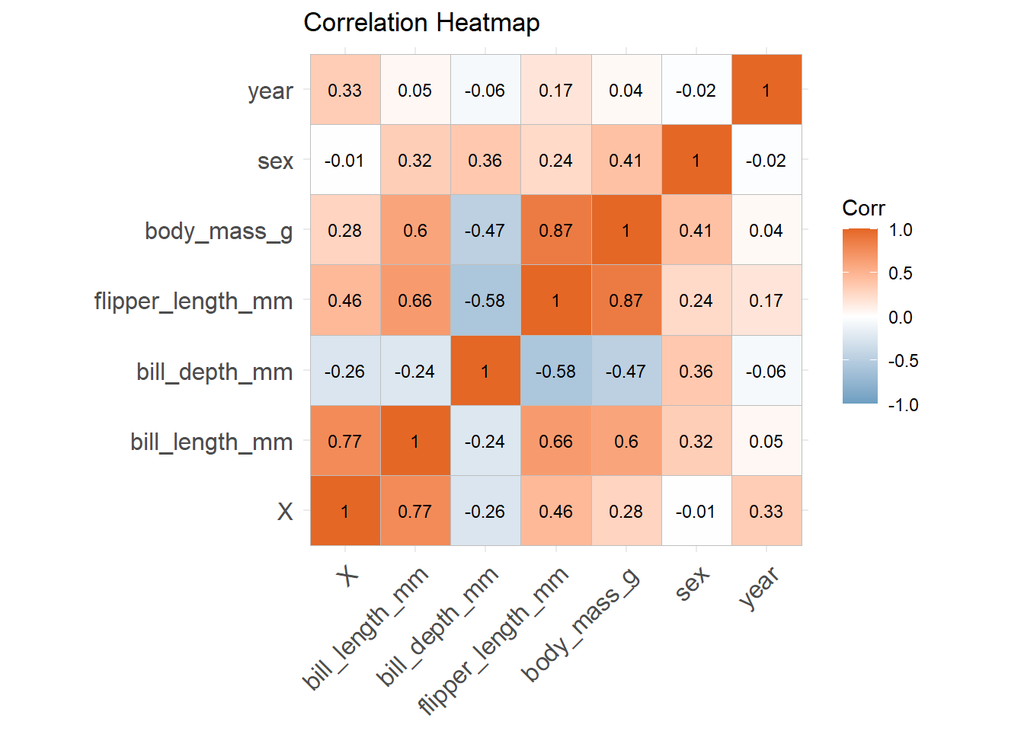

```r
# Calculate correlations between numeric variables
numeric_data <- data %>% select_if(is.numeric)
corr_matrix <- cor(numeric_data, use = "complete.obs")

# Plot the correlation heatmap
ggcorrplot(corr_matrix, method = "square", type = "full", lab = TRUE, lab_size = 3,
           colors = c("#6D9EC1", "white", "#E46726"), title = "Correlation Heatmap")
```

1. **Bill Length and Flipper Length**: There is a strong positive correlation between bill length and flipper length. This suggests that penguins with longer bills tend to have longer flippers.
2. **Body Mass and Flipper Length**: A strong positive correlation exists between body mass and flipper length, indicating that heavier penguins tend to have longer flippers.

### **2.6. Unnecessary data**

The first column that symbolizes the penguin index and it is not going to help us when we make the clusters, so we are going to remove this column.

```r
# Remove the first column (X)
data <- data %>% select(-X)
```

Let’s see the data after removing the column.

```r
# Display the dataframe after deletion
summary(data)
```

```
##  bill_length_mm  bill_depth_mm   flipper_length_mm  body_mass_g
##  Min.   :32.10   Min.   :13.10   Min.   :172.0     Min.   :2700
##  1st Qu.:39.23   1st Qu.:15.60   1st Qu.:190.0     1st Qu.:3550
##  Median :44.45   Median :17.30   Median :197.0     Median :4050
##  Mean   :43.92   Mean   :17.15   Mean   :200.9     Mean   :4202
##  3rd Qu.:48.50   3rd Qu.:18.70   3rd Qu.:213.0     3rd Qu.:4750
##  Max.   :59.60   Max.   :21.50   Max.   :231.0     Max.   :6300
##       sex             year
##  Min.   :1.000   Min.   :1.000
##  1st Qu.:1.000   1st Qu.:1.000
##  Median :2.000   Median :2.000
##  Mean   :1.518   Mean   :2.029
##  3rd Qu.:2.000   3rd Qu.:3.000
##  Max.   :2.000   Max.   :3.000
```

Now we have the dataset cleaned.

## **3. Clustering Models**

### **3.1. Normalization and Transformation**

Here we scale the numeric columns. Using scaling is often better because it ensures that all features have the same mean (0) and standard deviation (1), making them contribute equally to distance-based algorithms like k-means, regardless of their original units or range. This prevents features with larger ranges from dominating the model.

```r
# Scaling the data
features <- data[, c("sex", "year", "bill_length_mm", "bill_depth_mm", "flipper_length_mm", "body_mass_g")]
data_scaled <- scale(features)
```

### **3.2. Models**

Once we have prepared the data, it is ready to be analized by clustering. We are going to use the following models:

- Hierarchical:
  - AGNES
- Partitional:
  - K-Means.
  - PAM
  - Gaussian Mixture Model
- Ordering-Based
  - OPTICS
- Density-Based
  - DBSCAN

#### **Optimal Number of Clusters**

First of all, we have to find the optimal number of clusters. To achieve this, we must do a pre-clustering. we are using the wss method.It measures the sum of the distances within each cluster. The optimal number of clusters is the one where the reduction in the sum of squares slows down.

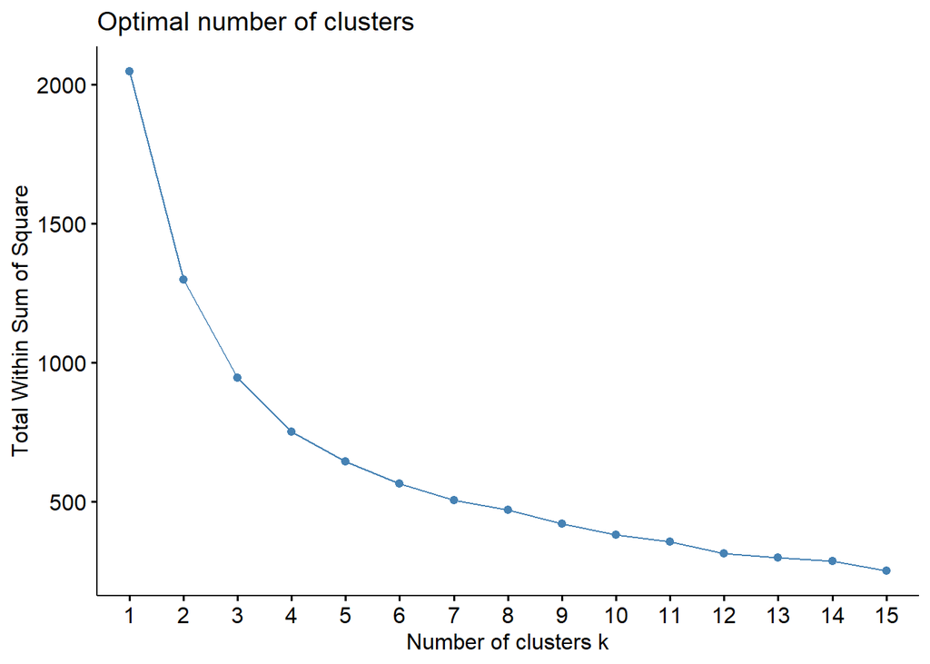

```r
fviz_nbclust(
  x = data_scaled, FUNcluster = cluster::pam, method = "wss", k.max = 15,
  diss = dist(data_scaled, method = "euclidean")
)
```

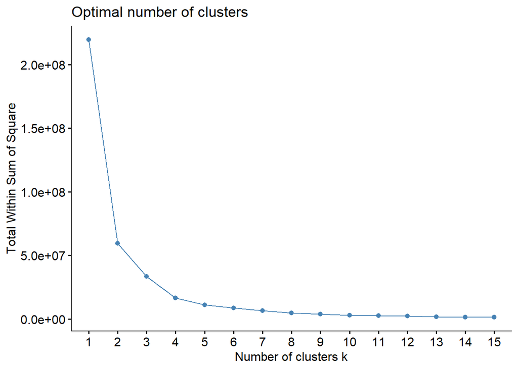

```r
fviz_nbclust(
  x = data, FUNcluster = cluster::pam, method = "wss", k.max = 15,
  diss = dist(data, method = "euclidean")
)
```

Here we can see how, beyond 5 clusters, the trend stabilizes. So we can conclude that 4 are the optimal number of clusters.

#### **Linkage**

Linkage is a method used in **hierarchical clustering** to determine the distance between clusters when grouping data. It defines how the distance between two sets of observations (clusters) is calculated, influencing the shape and structure of the resulting dendrogram. Common linkage methods include:

There are five types of linkages:

- **Complete Linkage**: Considers the maximum distance between points of different clusters.
- **Single Linkage**: Uses the minimum distance between points.
- **Average Linkage**: Calculates the average of the distances. Also we implemented with Euclidean and Manhattan distances.
- **Centroid linkage clustering**: Find the centroid of each cluster and calculate the distance between the centroids of two different clusters.
- **Ward’s minimum variance method**: Instead of measuring the distance directly, it analyzes the variance of clusters. It minimizes the total within-cluster variance. At each step the pair of clusters with minimum between-cluster distance are merged.

We will see four linkages:

With Euclidean distance.

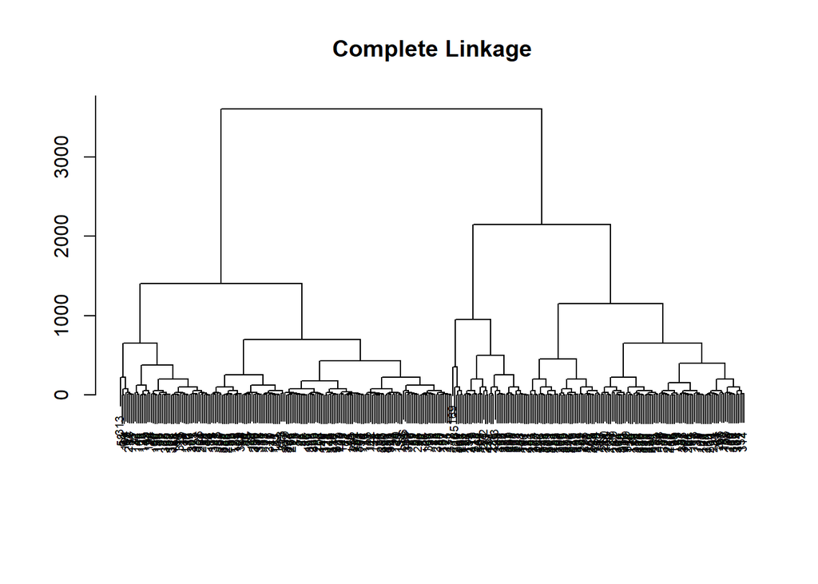

```r
matriz_distancias <- dist(x = data, method = "euclidean")

hc_euclidea_completo <- hclust(d = matriz_distancias, method = "complete")
hc_euclidea_single <- hclust(d = matriz_distancias, method = "single")
hc_euclidea_average <- hclust(d = matriz_distancias, method = "average")
hc_euclidea_ward <- hclust(d = matriz_distancias, method = "ward.D2")

plot(
  x = hc_euclidea_completo, cex = 0.6, xlab = "", ylab = "", sub = "",
  main = "Complete Linkage"
)
```

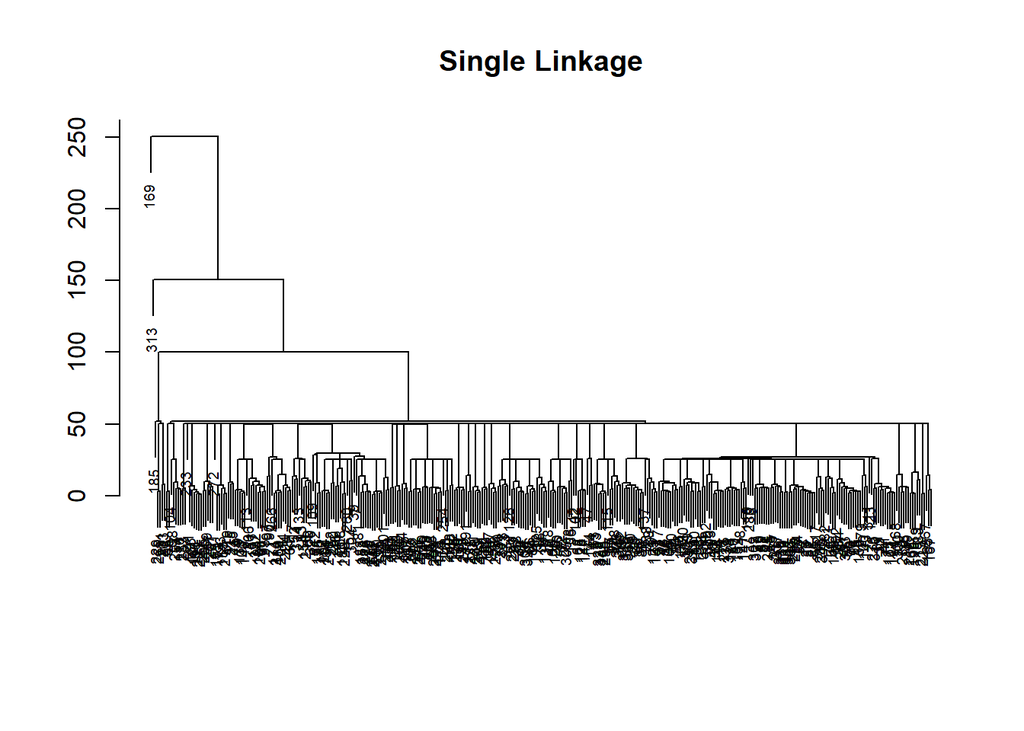

```r
plot(
  x = hc_euclidea_single, cex = 0.6, xlab = "", ylab = "", sub = "",
  main = "Single Linkage"
)
```

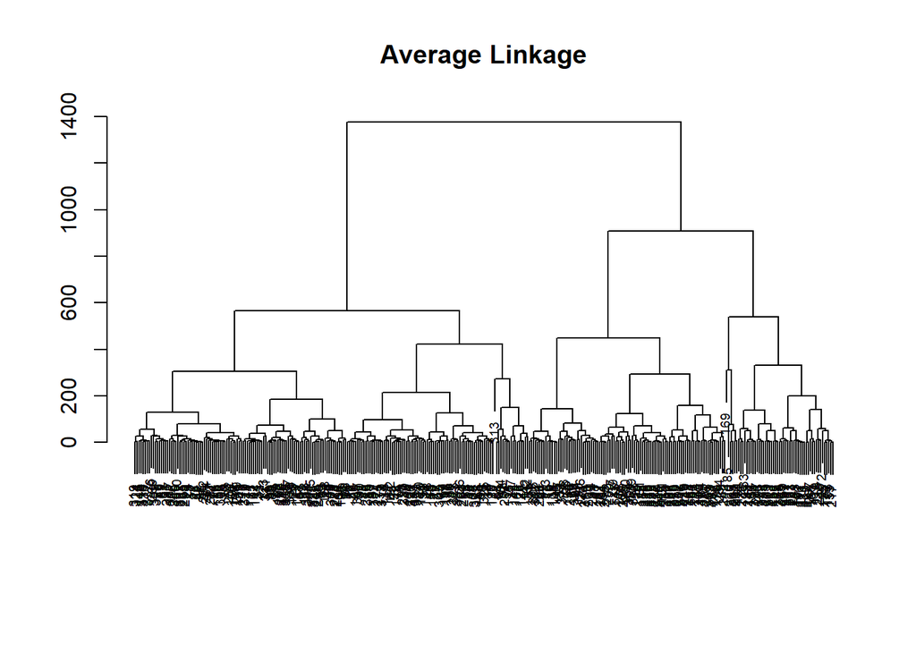

```r
plot(
  x = hc_euclidea_average, cex = 0.6, xlab = "", ylab = "", sub = "",
  main = "Average Linkage"
)
```

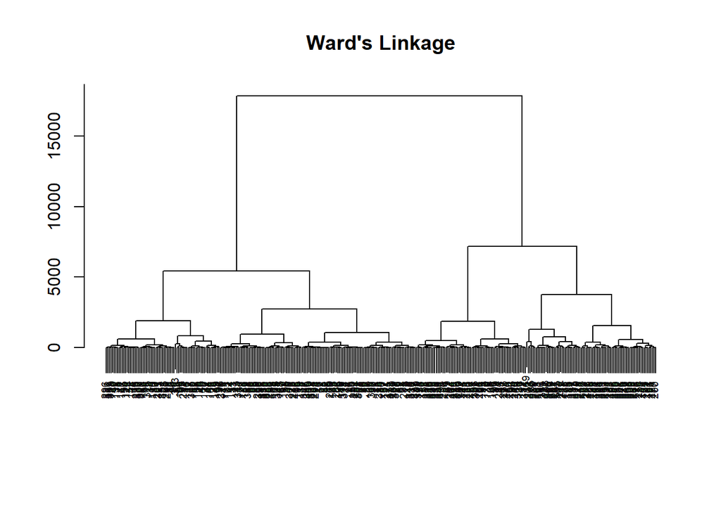

```r
plot(
  x = hc_euclidea_ward, cex = 0.6, xlab = "", ylab = "", sub = "",
  main = "Ward's Linkage"
)
```

With Manhattan distance.

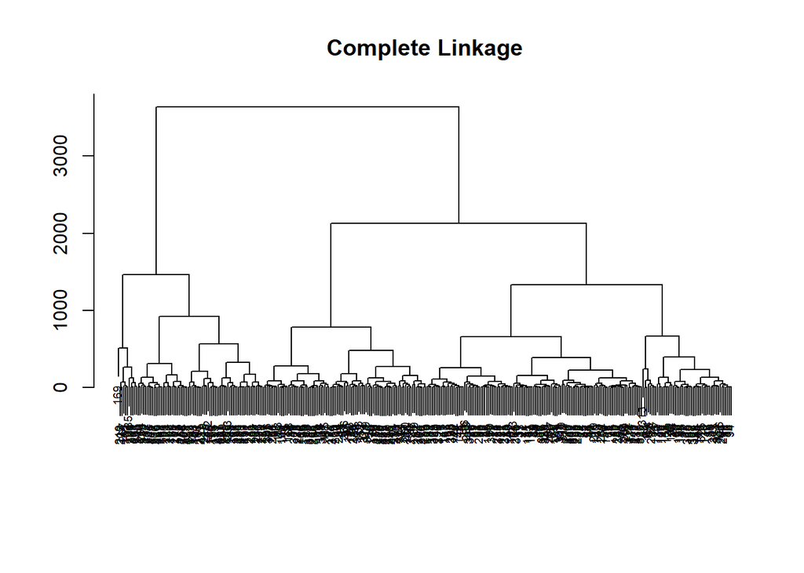

```r
matriz_distancias <- dist(x = data, method = "manhattan")

hc_manhattan_completo <- hclust(d = matriz_distancias, method = "complete")
hc_manhattan_single <- hclust(d = matriz_distancias, method = "single")
hc_manhattan_average <- hclust(d = matriz_distancias, method = "average")
hc_manhattan_ward <- hclust(d = matriz_distancias, method = "ward.D2")


plot(
  x = hc_manhattan_completo, cex = 0.6, xlab = "", ylab = "", sub = "",
  main = "Complete Linkage"
)
```

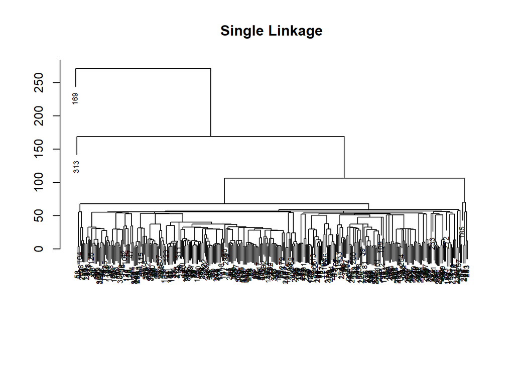

```r
plot(
  x = hc_manhattan_single, cex = 0.6, xlab = "", ylab = "", sub = "",
  main = "Single Linkage"
)
```

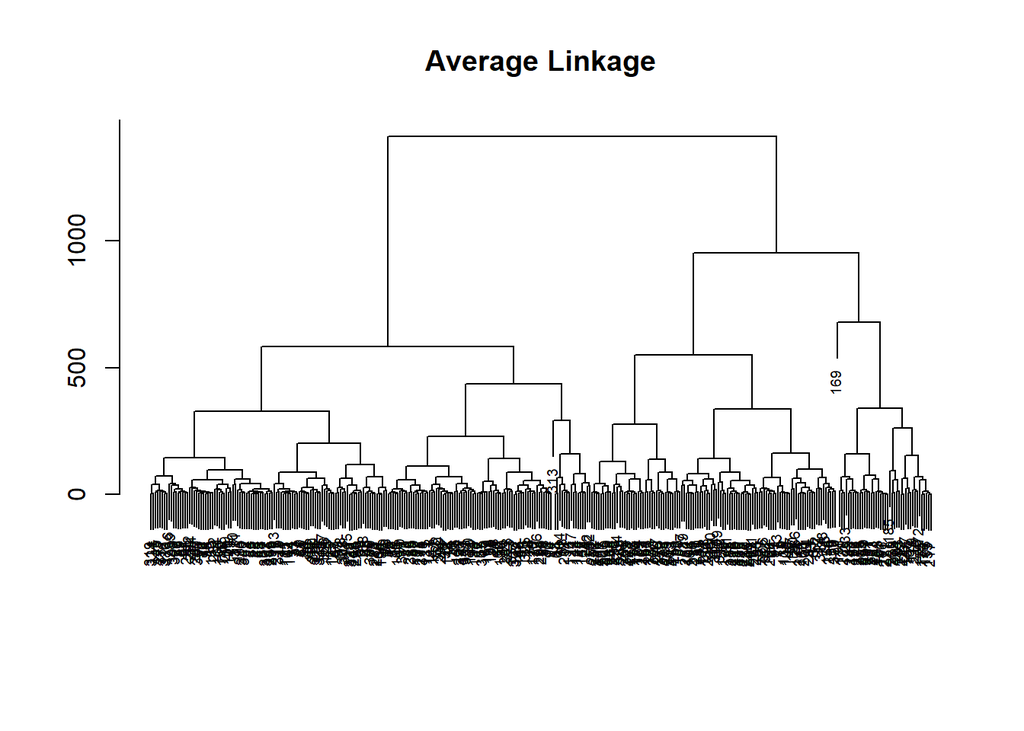

```r
plot(
  x = hc_manhattan_average, cex = 0.6, xlab = "", ylab = "", sub = "",
  main = "Average Linkage"
)
```

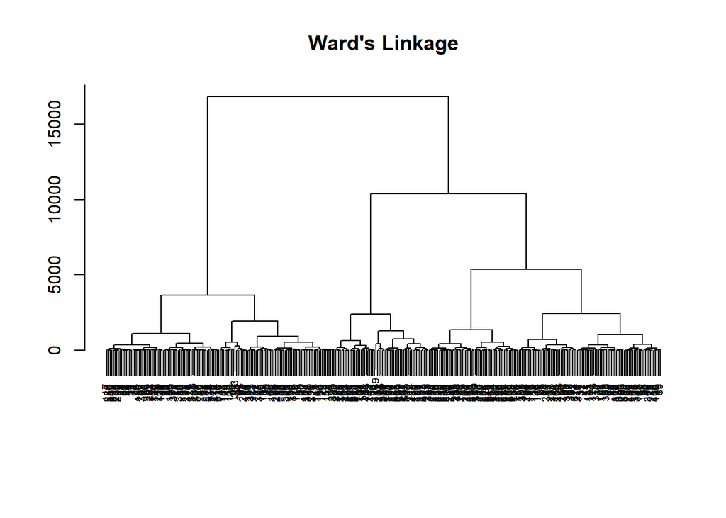

```r
plot(
  x = hc_manhattan_ward, cex = 0.6, xlab = "", ylab = "", sub = "",
  main = "Ward's Linkage"
)
```

**1. Method recommendation**

- For this dataset, Average Linkage appears to be the most appropriate, as it generates balanced clusters and captures relationships between variables without being overly influenced by outliers.

**2. Optimal number of clusters**

- The optimal number of clusters was identified to be between 3 and 4, depending on the desired granularity. This is in line with the results of the partitional analysis.

**3. Preferred distance**

- Although Manhattan is preferable for partitional models, Euclidean proved to be effective for hierarchical linkage, especially with methods such as Complete and Average.

**4. Interpretation of clusters**

- Each generated cluster can be interpreted as a subpopulation of penguins with similar characteristics, based on beak lengths, body weight, and other metrics.

#### **3.2.1. Hierarchical**

##### **AGNES**

It merges the closest clusters iteratively, creating a dendrogram from individual points to a single cluster.

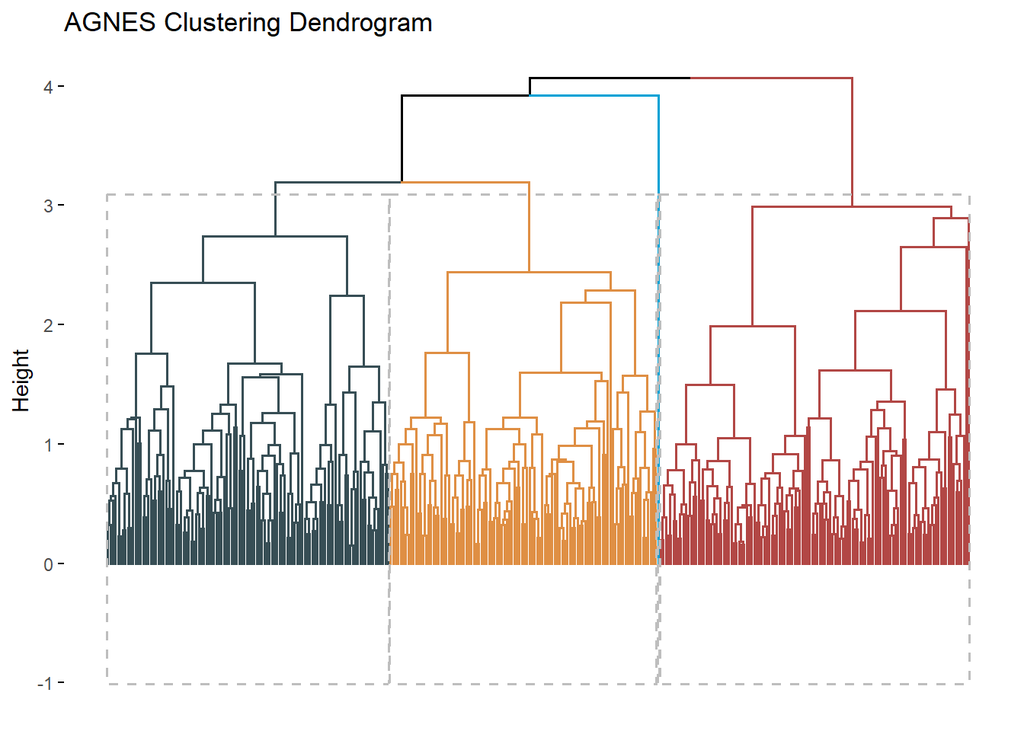

```r
agnes <- agnes(data_scaled)

fviz_dend(agnes,
  main = "AGNES Clustering Dendrogram",
  show_labels = FALSE,
  palette = "jama",
  k = 4,
  color_labels_by_k = TRUE,
  ggtheme = theme_classic(),
  rect = TRUE
)
```

Dividing the data into 4 clusters allows for identifying more specific subgroups within the data. This can be useful if the analysis is looking for fine patterns or subcategories. We will still try with fewer clusters (2-3)

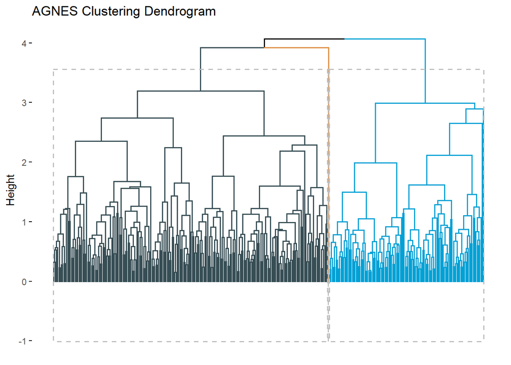

```r
fviz_dend(agnes,
  main = "AGNES Clustering Dendrogram",
  show_labels = FALSE,
  palette = "jama",
  k = 3,
  color_labels_by_k = TRUE,
  ggtheme = theme_classic(),
  rect = TRUE
)
```

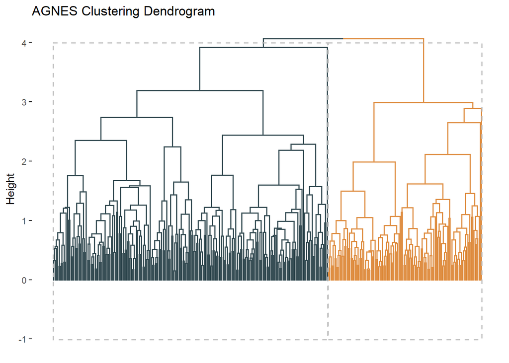

```r
fviz_dend(agnes,
  main = "AGNES Clustering Dendrogram",
  show_labels = FALSE,
  palette = "jama",
  k = 2,
  color_labels_by_k = TRUE,
  ggtheme = theme_classic(),
  rect = TRUE
)
```

With **3 clusters**: This is not the best because it is using one cluster just for one data. So is better to include it in another cluster.

With **2 clusters**: This configuration seems to be the most suitable, as it offers a clear and concise division. This can be useful if the goal is a simple but effective segmentation.

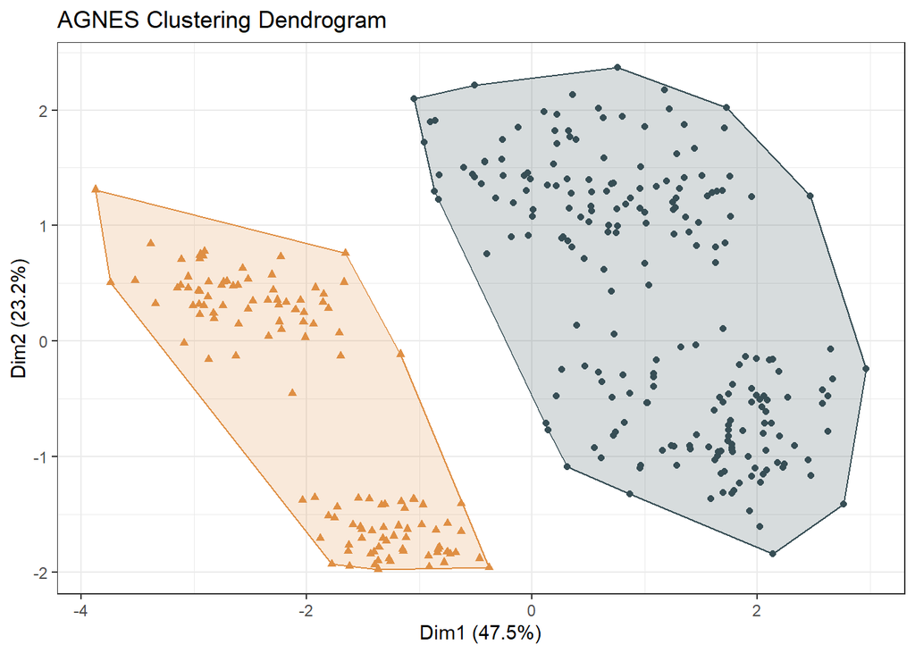

```r
cluster_labels <- cutree(as.hclust(agnes), k = 2)

# Visualize the clusters
fviz_cluster(
  object = list(data = data_scaled, cluster = cluster_labels),
  show.clust.cent = FALSE, # Agnes doesn't compute centroids
  ellipse.type = "convex", star.plot = FALSE, repel = TRUE, geom = "point",
  palette = "jama"
) +
  labs(title = "AGNES Clustering Dendrogram") +
  theme_bw() +
  theme(legend.position = "none")
```

When 2 clusters were selected, a clear and well-defined split was observed, suggesting that this configuration captures the main divisions in the data, so let’s see graphically how these groups separate.

The visualization in two-dimensional space (final graph) shows that the data are grouped into two well-separated regions, represented by triangles and points.

The percentages on the axes (47.5% and 23.2%) indicate that these two dimensions explain a significant proportion of the variability in the data.

#### **3.2.2. Partitional**

##### **K-Means**

First, we are going to compare this model with 3 and 4 clusters to see which is better.

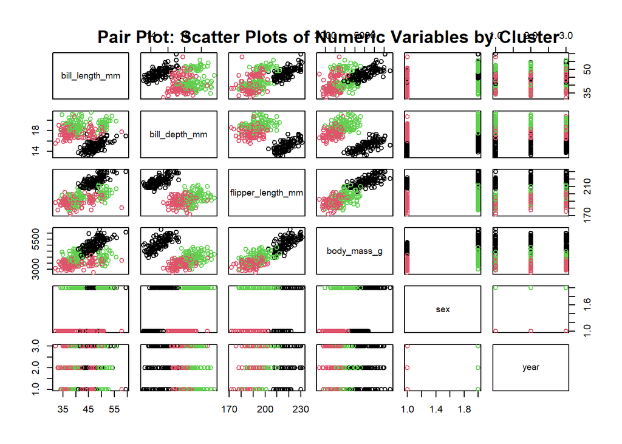

```r
k1 <- 3
kmeans <- kmeans(data_scaled, centers = k1, nstart = 2)
data$cluster <- kmeans$cluster

plot(data[, c(1:6)], col = kmeans$cluster)
title("Pair Plot: Scatter Plots of Numeric Variables by Cluster")
```

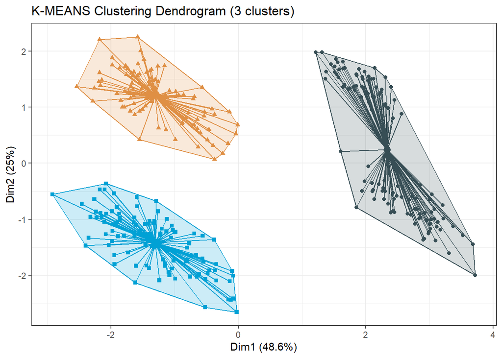

```r
fviz_cluster(
  object = kmeans, data = data, show.clust.cent = TRUE,
  ellipse.type = "convex", star.plot = TRUE, repel = TRUE, geom = "point",
  palette = "jama"
) +
  labs(title = "K-MEANS Clustering Dendrogram (3 clusters)") +
  theme_bw() +
  theme(legend.position = "none")
```

With 3 clusters seems good, but maybe with 4 we divide it better.

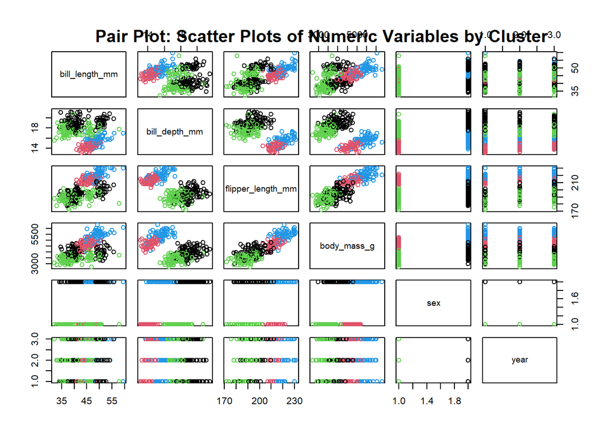

```r
k2 <- 4
kmeans2 <- kmeans(data_scaled, centers = k2, nstart = 2)
data$cluster <- kmeans2$cluster

plot(data[, c(1:6)], col = kmeans2$cluster)
title("Pair Plot: Scatter Plots of Numeric Variables by Cluster")
```

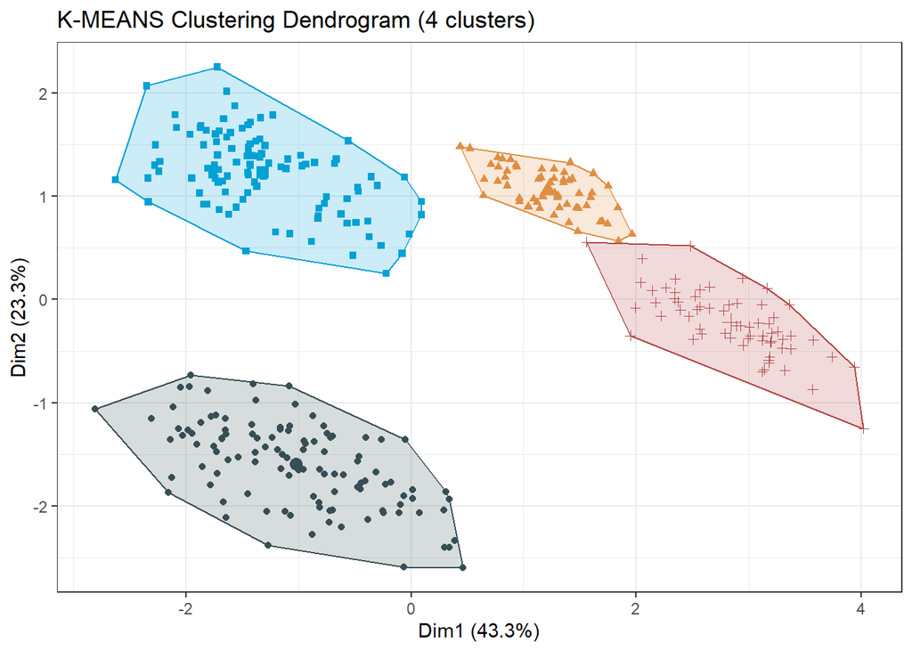

```r
fviz_cluster(
  object = kmeans2, data = data, show.clust.cent = TRUE,
  ellipse.type = "convex", star.plot = FALSE, repel = FALSE,
  geom = "point",
  palette = "jama"
) +
  labs(title = "K-MEANS Clustering Dendrogram (4 clusters)") +
  theme_bw() +
  theme(legend.position = "none")
```

With 4 clusters we can consider is better because the data is perfectly divided. To illustrate why 5, 6 or 7 clusters do not improve this division, we are going to watch it visually.

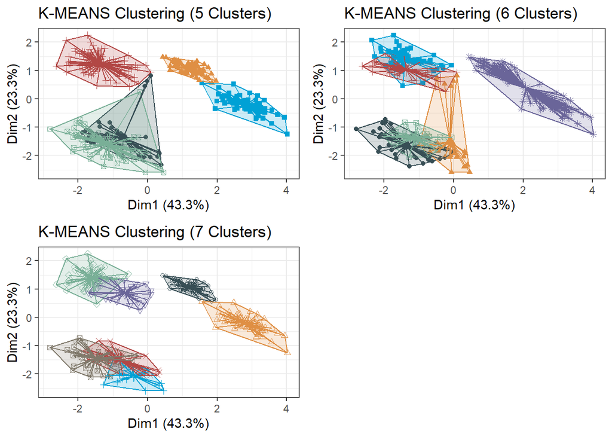

```r
kmeans_5 <- kmeans(data_scaled, centers = 5, nstart = 2)
plot_5 <- fviz_cluster(
  object = kmeans_5, data = data, show.clust.cent = TRUE,
  ellipse.type = "convex", star.plot = TRUE, repel = TRUE,
  geom = "point",
  palette = "jama"
) +
  labs(title = "K-MEANS Clustering (5 Clusters)") +
  theme_bw() +
  theme(legend.position = "none")

kmeans_6 <- kmeans(data_scaled, centers = 6, nstart = 2)
plot_6 <- fviz_cluster(
  object = kmeans_6, data = data, show.clust.cent = TRUE,
  ellipse.type = "convex", star.plot = TRUE, repel = TRUE,
  geom = "point",
  palette = "jama"
) +
  labs(title = "K-MEANS Clustering (6 Clusters)") +
  theme_bw() +
  theme(legend.position = "none")

kmeans_7 <- kmeans(data_scaled, centers = 7, nstart = 2)
plot_7 <- fviz_cluster(
  object = kmeans_7, data = data, show.clust.cent = TRUE,
  ellipse.type = "convex", star.plot = TRUE, repel = TRUE,
  geom = "point",
  palette = "jama"
) +
  labs(title = "K-MEANS Clustering (7 Clusters)") +
  theme_bw() +
  theme(legend.position = "none")

# Combine the graphs into a grid
grid.arrange(plot_5, plot_6, plot_7, ncol = 2)
```

We can watch how adding more number of clusters does not improve the division of the data, because some clusters are mixed and can be joined.

Finally, a dendrogram is shown to see perfectly the 4 clusters.

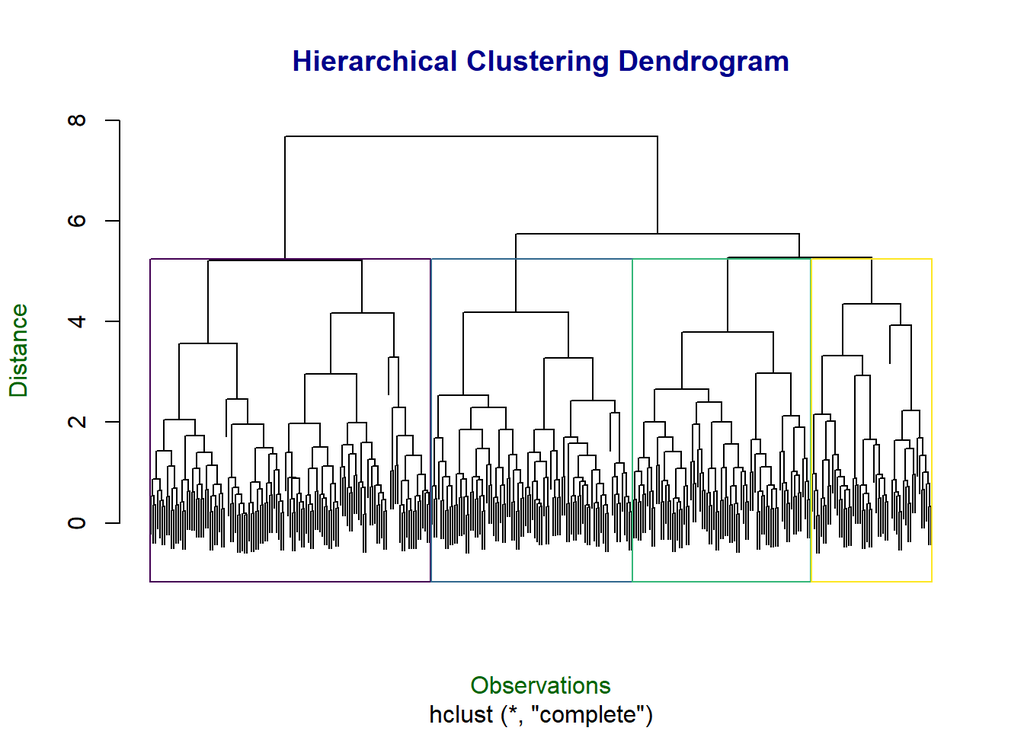

```r
hclust_result <- hclust(dist(data_scaled))
plot(hclust_result, cex = 0.6, main = "Hierarchical Clustering Dendrogram",
     xlab = "Observations", ylab = "Distance",
     col.main = "darkblue", col.lab = "darkgreen", labels = FALSE)
rect.hclust(hclust_result, k = 4, border = viridis(4, option = "jama"))
```

The presented dendrogram shows the result of a hierarchical clustering analysis using the distance metric applied to scaled data. Four main clusters are highlighted, as indicated by the rectangles around the branches.

The hierarchical structure indicates that the 4 selected groups have a good separation. This suggests that there are significant differences between them. Each cluster contains observations that are more related to each other than to the data in other clusters.

##### **PAM**

This model groups data by selecting representative points (medoids) as the centers of clusters. It minimizes the sum of dissimilarities between points and their corresponding medoid. We are trying with 3 and 4 clusters:

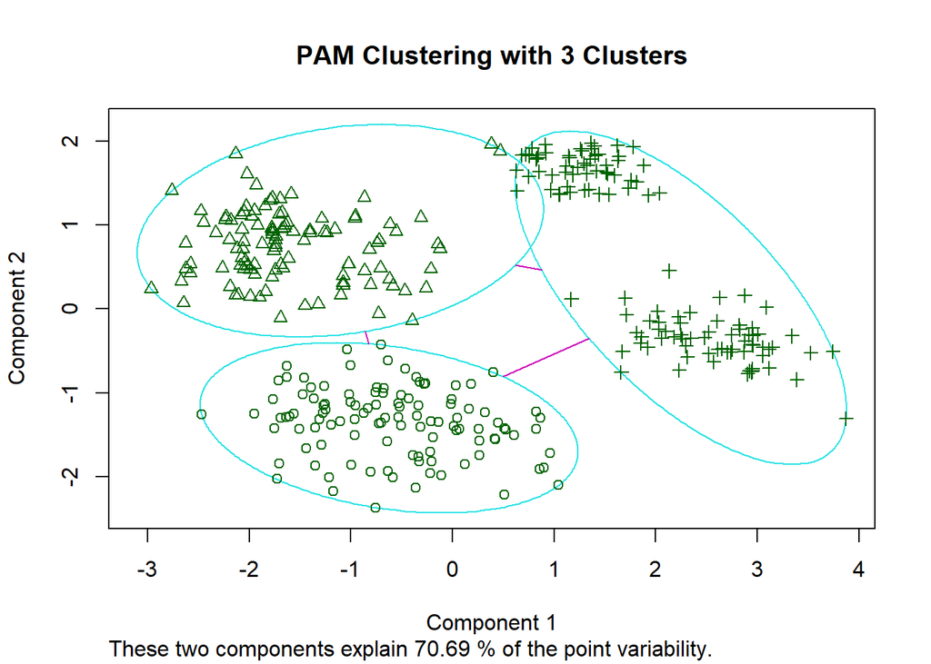

```r
pam <- pam(dist(data_scaled, method = "euclidean"), 3)
clusplot(pam, main = "PAM Clustering with 3 Clusters")
```

The Silhouette Plot evaluates how well each point is assigned to its respective cluster. A large $s_i$ (close to 1) indicates that the point is well clustered, a small $s_i$(around 0) means the point lies between two clusters, and a negative $s_i$ suggests misclassification. While the horizontal bars are not visible in the provided plots, the numerical values and average silhouette widths still provide meaningful insights into the quality of clustering and allow us to effectively evaluate and compare the results of the different models.

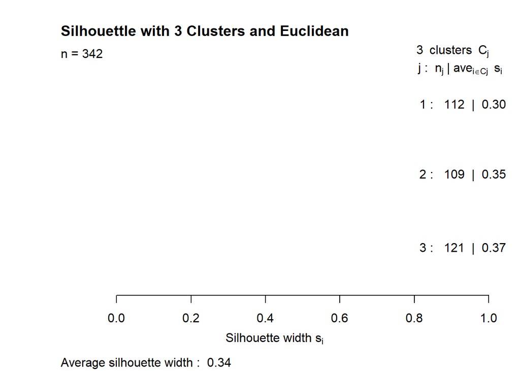

```r
plot(pam, main = "Silhouettle with 3 Clusters and Euclidean")
```

In this first analysis (Euclidean distance, 3 clusters), the average silhouette width is 0.34, indicating a weak clustering. Cluster 3 has the highest silhouette width (0.37), suggesting it is relatively better clustered, while clusters 1 (0.30) and 2 (0.35) show significant overlap.

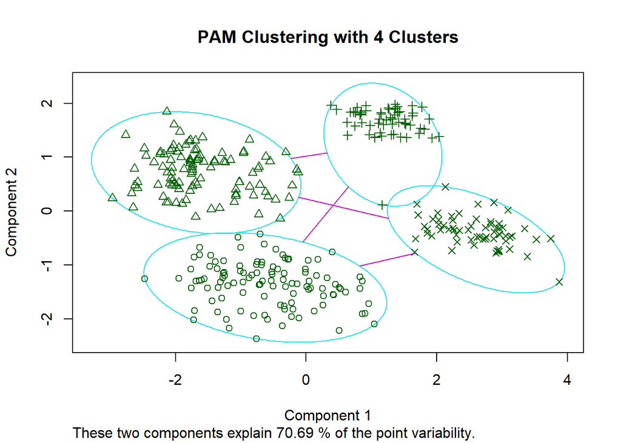

```r
pam <- pam(dist(data_scaled, method = "euclidean"), 4)
clusplot(pam, main = "PAM Clustering with 4 Clusters")
```

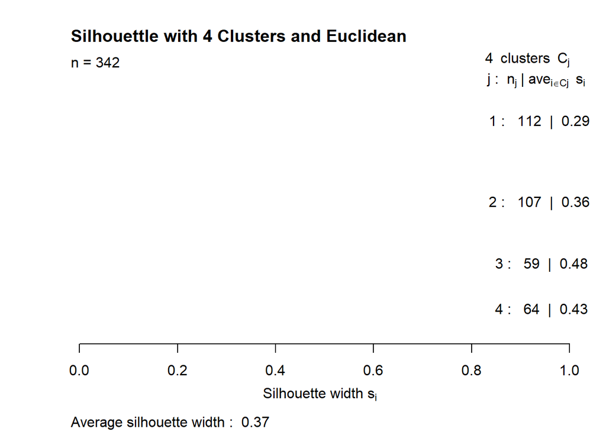

```r
plot(pam, main = "Silhouettle with 4 Clusters and Euclidean")
```

In this second analysis (Euclidean distance, 4 clusters), the silhouette width slightly improves to 0.37. Cluster 3 has the highest silhouette width (0.48), showing it is well-separated. However, other clusters, particularly cluster 1 (0.29), remain weakly defined and overlap with others.

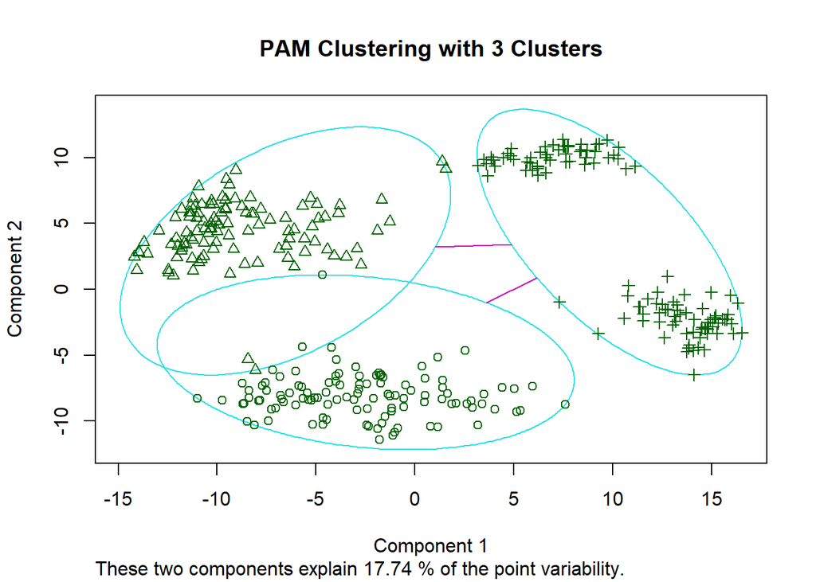

```r
pam <- pam(dist(data_scaled, method = "manhattan"), 3)
clusplot(pam, main = "PAM Clustering with 3 Clusters")
```

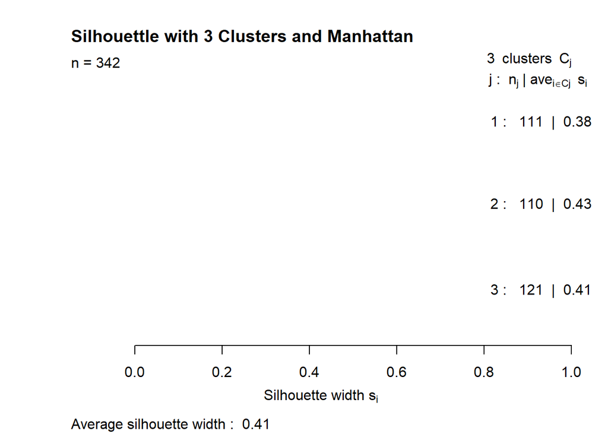

```r
plot(pam, main = "Silhouettle with 3 Clusters and Manhattan")
```

In this third analysis (Manhattan distance, 3 clusters), the average silhouette width increases to 0.41, reflecting better clustering. Clusters 2 (0.43) and 3 (0.41) show better separation, while cluster 1 (0.38) still experiences some overlap.

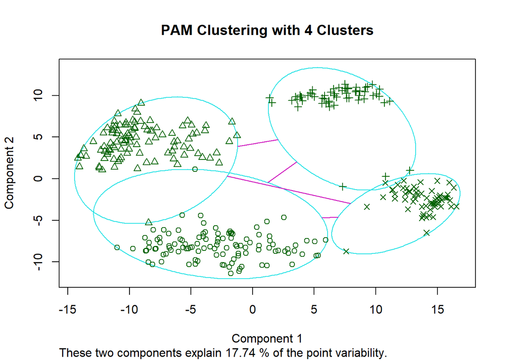

```r
pam <- pam(dist(data_scaled, method = "manhattan"), 4)
clusplot(pam, main = "PAM Clustering with 4 Clusters")
```

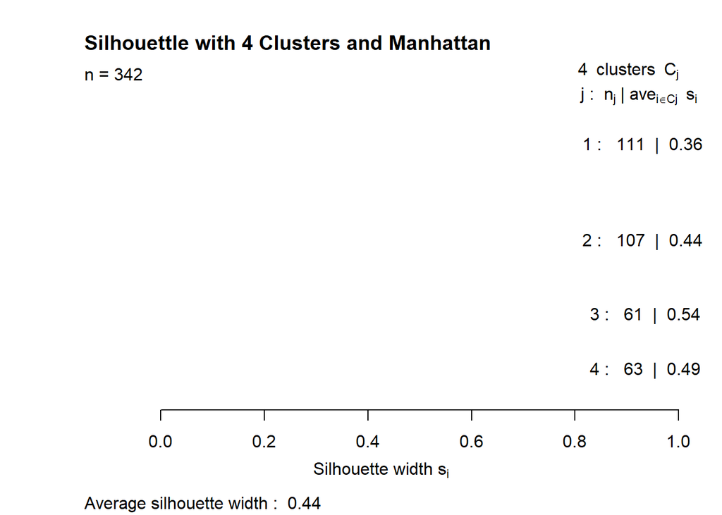

```r
plot(pam, main = "Silhouettle with 4 Clusters and Manhattan")
```

Finally, in this fourth analysis (**Manhattan distance, 4 clusters**), the silhouette width further improves to 0.44, indicating the best clustering among all configurations. Cluster 3 (0.54) and cluster 4 (0.49) are well-separated, while cluster 1 (0.36) still shows some ambiguity.

The 3-cluster PAM model offers a simpler segmentation, suitable for general insights and less detailed analysis. It is easier to interpret but struggles with overlapping clusters and less defined boundaries, particularly when using Euclidean distance. On the other hand, the 4-cluster model provides a more refined representation of the data structure, with clearer separations and better-defined groupings, especially when using Manhattan distance. This configuration captures additional nuances within the data, making it more suitable for detailed and specific analyses.

While the 3-cluster model is sufficient for broader overviews and simplicity, the 4-cluster model is recommended when a higher level of granularity is needed to uncover more subtle differences. The choice ultimately depends on the depth of analysis required.

##### **Gaussian Mixture Model**

This is a probabilistic model that assumes the data is generated from a mixture of several Gaussian distributions with unknown parameters. It estimates the parameters using the Expectation-Maximization (EM) algorithm to assign data points to different clusters based on their likelihood.

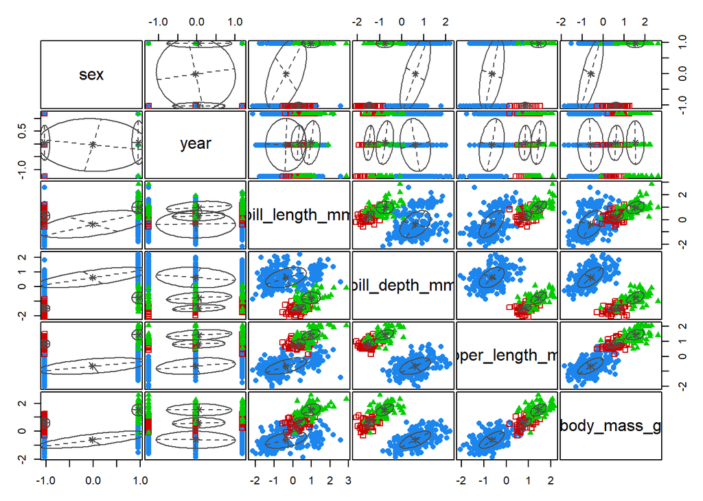

```r
gaussian <- Mclust(data_scaled)
plot(gaussian, what = "classification", main = "GMM Clustering")
```

The ellipses encapsulating the data in each cluster reflect the probabilities calculated by the model. This indicates that the model not only assigns points to clusters, but also provides a measure of uncertainty. Unlike methods such as K-means or PAM, GMM uses a probabilistic approach, making it more suitable in scenarios where clusters may overlap or when the shape of the clusters is not necessarily spherical.

In this case, three distinct clusters are identified, whereas in other instances, four clusters are found. Furthermore, in some situations, individual clusters could be combined into a single cluster.

Variables such as bill_length_mm, bill_depth_mm, flipper_length_mm, and body_mass_g show notable differences between clusters, indicating that these features are important for classification.

#### **3.2.3. Ordering-Based**

##### **OPTICS**

OPTICS is so similar to DBSCAN, but it handles varying density clusters better. It produces an ordering of points that reveals the structure of the data, allowing the identification of clusters at different density levels without needing a predefined distance threshold.

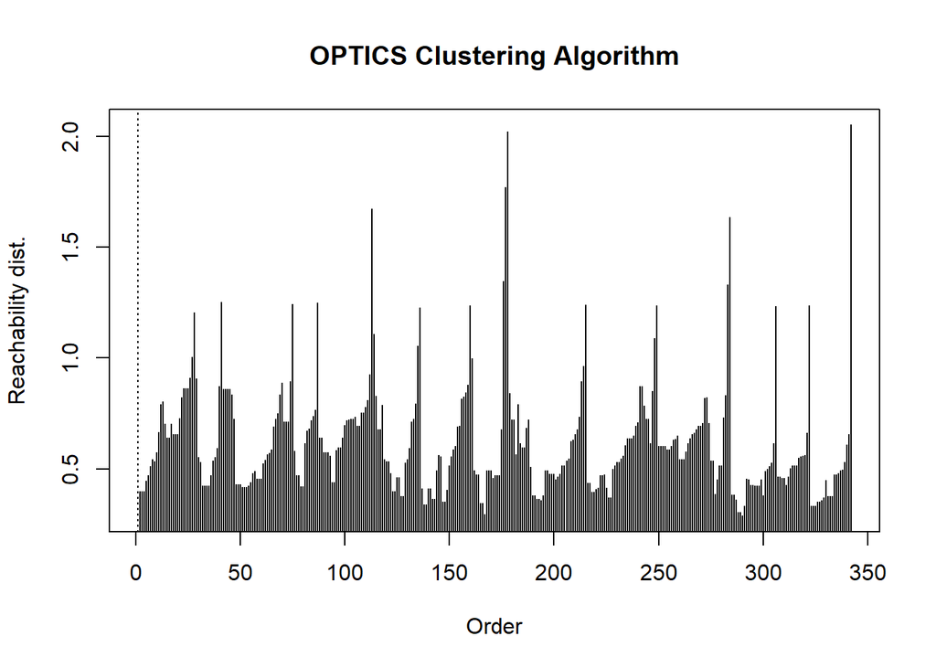

```r
optics <- optics(data_scaled, minPts = 4)
plot(optics, main = "OPTICS Clustering Algorithm")
```

With this algorithm, the clusters aren’t easily distinguishable due to the diverse and widely spread valleys. However, it is apparent that there are four prominent peaks, which suggest the existence of 4 distinct clusters within the data.

#### **3.2.4. Density-Based**

##### **DBSCAN**

This is a clustering algorithm that groups together points that are closely packed, marking as outliers those that lie alone in low-density regions.

The results depend on the parameters eps (neighborhood radius) and minPts (minimum points to form a cluster). A more thorough evaluation could explore how these parameters affect the number of clusters and the detection of outliers.

```r
dbscan <- dbscan(data_scaled,
  eps = 1.5,
  MinPts = 4
)
```

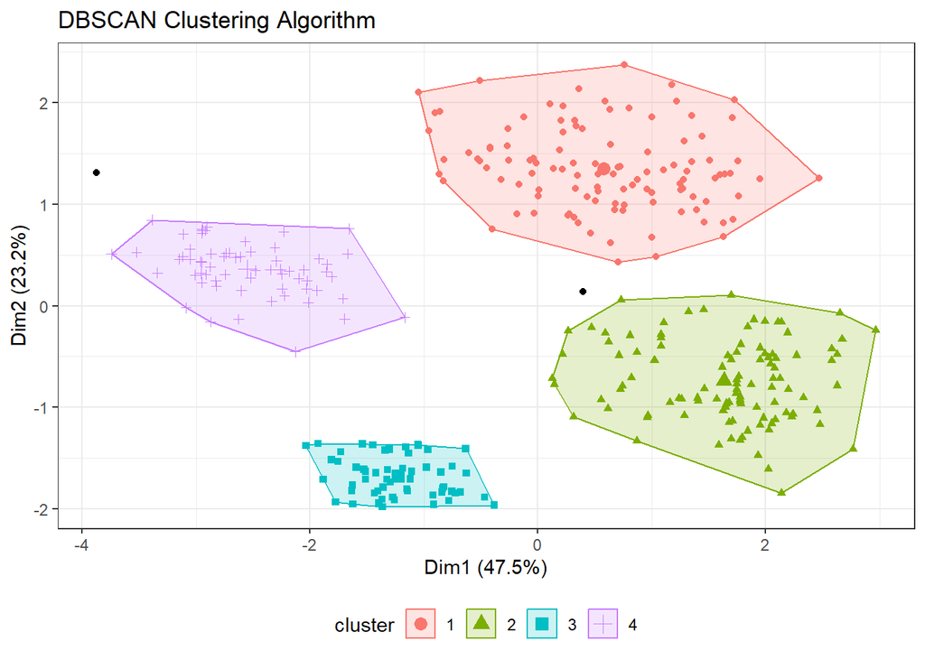

```r
fviz_cluster(
  object = dbscan, data = data_scaled, stand = FALSE,
  geom = "point", ellipse = TRUE, show.clust.cent = TRUE,
  pallete = "jco",
  main = "DBSCAN Clustering Algorithm"
) +
  theme_bw() +
  theme(legend.position = "bottom")
```

This model has divided automatically the data into 4 clusters, and has identified 2 outliers, which are the black points. This shows that DBSCAN is effective in detecting noise or outliers in the data.

The clusters are compact and well separated, indicating that densities within each group are significantly higher than in the regions between them. The ellipses drawn around the clusters reinforce this observation.

## **4. Conclusions**

Different clustering techniques were applied in this analysis, classified according to their methodological approaches. Each model offered a unique perspective on the structure of the data. The conclusions are presented below, organized by category:

**1. Hierarchical: AGNES**

- The AGNES model allowed the identification of 4 well-defined clusters, showing a clear and useful hierarchical structure to understand the relationships between observations at different clustering levels.

- This method is particularly valuable when a hierarchical representation is sought and the number of clusters is not previously known.

**2. Partitional**

**2.1 K-Means:**

- Provided compact and separate clusters, being especially computationally efficient. The configuration with 4 clusters showed the best segmentation in this analysis.

- However, its dependence on centroids makes it less robust against outliers or non-spherical distributions.

**2.2 PAM (Partitioning AroundMedoids):**

- Similar to K-Means in terms of overall cluster quality but more robust against outliers, as it uses medoids instead of centroids to define clusters. This makes it better suited for datasets with irregular distributions or noise.

- This method also identified 4 clusters as the optimal configuration, offering a stable and reliable option for accurate segmentations, especially in datasets with complex characteristics.

**2.3 Gaussian Mixture Model (GMM):**

- This probabilistic model identified 3 main clusters, with flexibility to model non-spherical clusters. However, it does not detect outliers explicitly and depends on correct parameter estimation.

**3. Ordering-Based: OPTICS**

OPTICS is especially effective on data with clusters of different densities. The analysis suggested the existence of 4 clusters, with a more complex structure than that identified by partitional models.

- Advantages:

- It does not require a fixed number of clusters a priori and is suitable for non-homogeneous data.

- Limitations:

- Its visualization requires careful interpretation to determine the clusters.

**4. Density-Based: DBSCAN**

DBSCAN identified 4 clusters and detected 2 outliers, highlighting its ability to handle noise and group data with irregular shapes.

- Advantages:

- It does not depend on the shape or size of the clusters and is ideal for data sets with significant noise.

-Limitations:

- The results depend strongly on the parameters eps and minPts.

General Conclusion

Each technique provides value depending on the characteristics of the data and the objectives of the analysis. For this particular dataset:

- **DBSCAN and OPTICS** stand out in their ability to handle variable densities and noise, being ideal for complex scenarios.
- **PAM and AGNES** offer consistent results with 4 clusters, being more suitable for homogeneous data and exploratory analysis.
- **K-Means and GMM** are fast and useful options in contexts where simplicity or basic segmentation is sought.

The choice of model will depend on the final purpose of the analysis, but the models that consistently identified 4 clusters appear to be the most representative of the dataset structure. It is recommended to complement this analysis with validation metrics to confirm the quality of the clusters obtained.